# Random Variables for Parasite Infection Dynamics

### The Distribution Function, `pAoI`

The distribution function for $A_d(a)$ is:

$$F_A(a) \sim \int_0^\alpha f_A(\alpha; a, d) d\alpha$$

```r
F_A = pAoI(a3years, max(a3years), FoI_a)
```

If our functions work correctly, then we should get approximately the same answer from computing the cumulative sum of `dAoI.`

```r
F_A_alt = cumsum(f_A)
```

We shouldn’t expect the answers to be exactly the same, but they should be close, with the `pAoI` in black.

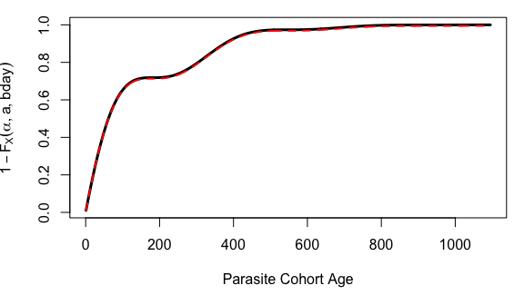

[figure not shown]

```r
par(mar = c(5,4,1,1))

plot(a3years, F_A, type = "l",
     xlab = "Parasite Cohort Age",
     ylab = expression(1-F[X](alpha, a, bday)), lwd=3)

lines(a3years, F_A_alt, col = "red", lwd=2, lty =2)
```

### Random Numbers, `rAoI`

The function `rAoI` uses `pAoI` to generate random numbers from $F_A(\alpha)$

```r
rhx = rAoI(10000, 3*365, FoI_a)
```

A simple visual check computes the empirical CDF for the random variates against $F_A(\alpha)$ computed using `pAoI`

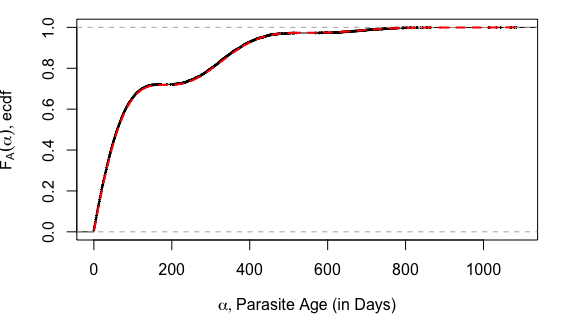

```r
par(mar = c(5,4,1,2))
plot(stats::ecdf(rhx), xlim = c(0,1095), cex=0.2, main = "",
     xlab = expression(list(alpha, paste("Parasite Age (in Days)"))),
     ylab = expression(list(F[A](alpha), paste("ecdf"))))
lines(a3years, F_A, col = "red", lty = 2, lwd=2)
```

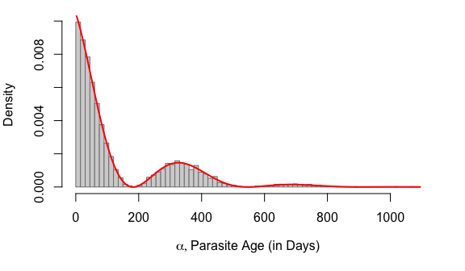

### AoI Moments

Let $x$ denote the first moment of of $A_d(a)$:
$$x_d(a) = \left< A_d(a) \right> =
\int_0^\infty \alpha \frac{z_d(\alpha, a)} {m_d(a)}$$

Similarly, we let $x_d(a)[n]$ denote the higher order moments of $A_d(a)$:
$$x_{[n]}(a, d) = \int_0^\infty \alpha^n
\frac{z_d(\alpha, a)} {m_d(a)}$$

```r
moment1 = momentAoI(a3years, FoI_a)
moment2 = momentAoI(a3years, FoI_a, n=2)
moment3 = momentAoI(a3years, FoI_a, n=3)
```

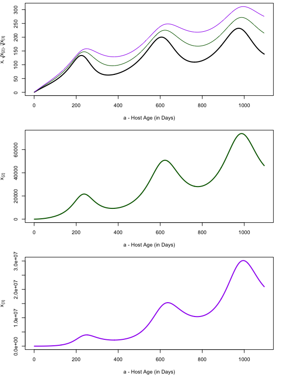

## Age of the Youngest Infection (AoY)

We have derived a random variable $Y_d(a)$ describing the age of the youngest infection (AoY). The density function for the AoY is:

$$Y_d(a) \sim f_Y(\alpha; a, d) =
f_A(\alpha, a,d) e^{-m_d(a) F_A(\alpha, a,d)}
\frac{m_d(a)}{p_d(a)}$$
The distribution function is:

$$F_Y(a) \sim
\frac{1-e^{-m_d(a)F_A(\alpha, a,d)}}{1-e^{-m_d(a)}} =
\frac{1-e^{-m_d(a)F_A(\alpha, a,d)}}{p_d(a)}$$

The derivations are found in a Suppplement to Henry JM, *et al.* (2024).

The mean AoY is:

$$\left< Y_d(a) \right> = \int_0^a \alpha \; f_Y(\alpha, a, d) \;
d\alpha$$

And the higher order moments for the AoY are:

$$\left< Y_d(a)^n \right> = \int_0^n
\alpha^n \; f_y(\alpha, a, d) \; d\alpha$$

### AoY Density, `dAoY`

The density function is computed with the function `dAoY.`

```r
f_Y = dAoY(a3years, 3*365, FoI_a)
```

We can compare $f_Y(\alpha)$ (in black) to $f_A(\alpha)$ (in grey).

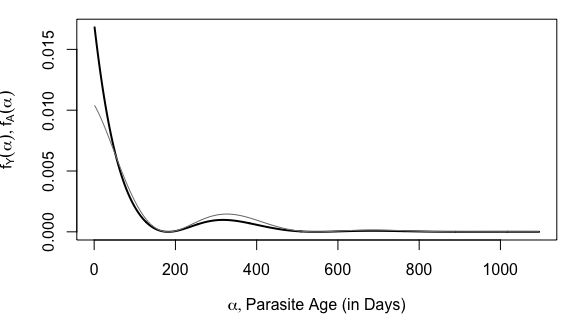

### Random Variables, `rAoY`

```r
raoy = rAoY(10^5, 3*365, FoI_a)
```

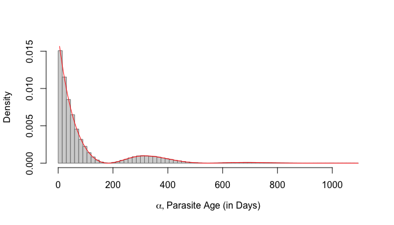

```r
hist(raoy, breaks=seq(0, 1095, by = 15),
     right=F, probability=T, main = "",
     xlab = expression(list(alpha, paste("Parasite Age (in Days)"))),
     border = grey(0.5)) -> out
lines(a3years, f_Y, type = "l", col = "red")
```

### AoY Moments

```r
aa = seq(5, 3*365, by = 5)
moment1y = momentAoY(aa, FoI_a)
moment2y = momentAoY(aa, FoI_a, n=2)
moment3y = momentAoY(aa, FoI_a, n=3)
```

The first three moments of the AoY plotted over time. In the top plot, we’ve also plotted the $n^{th}$ root of the $n^{th}$ moment.

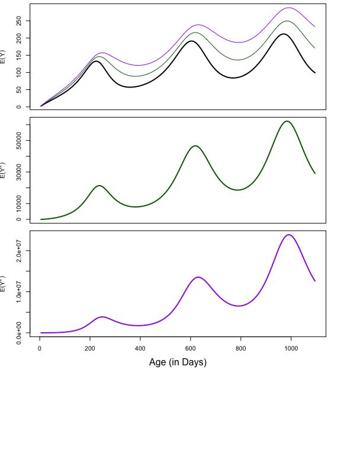

**Next:**

- In the vignette MoI, we show that the mean MoI computed using the formula in Eq. 2 gives the same answer as other approaches.
[^1]: Henry JM, Carter AR, Wu SL, Smith DL (in preparation). A Probabilistic Synthesis of Malaria Epidemiology: Exposure, Infection, Parasite Densities, and Detection.
[^2]: Nåsell I (1985). Hybrid Models of Tropical Infections, 1st edition. Springer-Verlag. https://doi.org/10.1007/978-3-662-01609-1